# Yinan_Kang_PS1

Yinan Kang (yik398@g.harvard.edu)

### Data

We will be using the [Stop, Question and Frisk Data from the NYPD](https://www1.nyc.gov/site/nypd/stats/reports-analysis/stopfrisk.page) which contains information about over 100,000 police citizen interactions between 2003-2016.

```r
# Let's first load the R packages and the data
library(bitops)
library(foreign)
library(RCurl)
stopandfrisk2016<-
  read.csv(
    text=getURL("https://raw.githubusercontent.com/ljanastas/WWS586A-Machine-Learning-Policy-Analysis/master/Data/stop-and-frisk2016.csv"),
           header=T)
```

### Background

Bill DeBlasio has come to you because he is interested in conducting an audit of some of the NYPD’s policies for frisking individuals suspected of criminar activity. He is particularly concerned that those indivduals that are frisked happen to be overwhelmingly African-American.

### 1: Summary statistics (30 Points)

As a first cut, DeBlasio would like to see summary statistics ($%$ of people frisked and $%$ of people not frisked) within each racial category.

In other words, of the people that are frisked, what percent are Black, White, Hispanic etc. Of the people that are not frisked, what percent are Black, White, Hispanic etc..

```r
attach(stopandfrisk2016)
library(dplyr)
# Check what Races were recorded, and if any NA's exist
unique(race)
```

```
[1] B W P A Q U Z I
Levels:   A B I P Q U W Z
```

```r
any(is.na(race))
```

```
[1] FALSE
```

```r
# Subset those who were frisked and not frisked
f <- stopandfrisk2016[frisked=="Y",]
n <- stopandfrisk2016[frisked=="N",]
f.a <- nrow(f[f$race=="A",]) / nrow(f) * 100
f.b <- nrow(f[f$race=="B",]) / nrow(f) * 100
f.i <- nrow(f[f$race=="I",]) / nrow(f) * 100
f.p <- nrow(f[f$race=="P",]) / nrow(f) * 100
f.q <- nrow(f[f$race=="Q",]) / nrow(f) * 100
f.u <- nrow(f[f$race=="U",]) / nrow(f) * 100
f.w <- nrow(f[f$race=="W",]) / nrow(f) * 100
f.z <- nrow(f[f$race=="Z",]) / nrow(f) * 100
n.a <- nrow(n[n$race=="A",]) / nrow(n) * 100
n.b <- nrow(n[n$race=="B",]) / nrow(n) * 100
n.i <- nrow(n[n$race=="I",]) / nrow(n) * 100
n.p <- nrow(n[n$race=="P",]) / nrow(n) * 100
n.q <- nrow(n[n$race=="Q",]) / nrow(n) * 100
n.u <- nrow(n[n$race=="U",]) / nrow(n) * 100
n.w <- nrow(n[n$race=="W",]) / nrow(n) * 100
n.z <- nrow(n[n$race=="Z",]) / nrow(n) * 100
```

**Summary of Results**:

Of those Frisked:  
5.4792795% were Race A  
54.6164504% were Race B  
0.2645169% were Race I  
7.3560902% were Race P  
22.3201915% were Race Q  
0.6046102% were Race U  
8.3007936% were Race W  
1.0580678% were Race Z

Of those Not Frisked:  
6.7637178% were Race A  
48.4210526% were Race B  
0.3807391% were Race I  
6.4725644% were Race P  
21.9708847% were Race Q  
1.0526316% were Race U  
13.6842105% were Race W  
1.2541993% were Race Z

### 2: Visualization (30 Points)

In addition to the summary statistics, the mayor would like you to produce two plots: a pie chart and a bar plot containing the percent of people within each racial group that were frisked.

Both the pie chart and the bar plot should have the title “Percent of Racial Group Frisked”.

Also, please save both plots as .png files. No need to submit the images, just make sure that the code is included below.

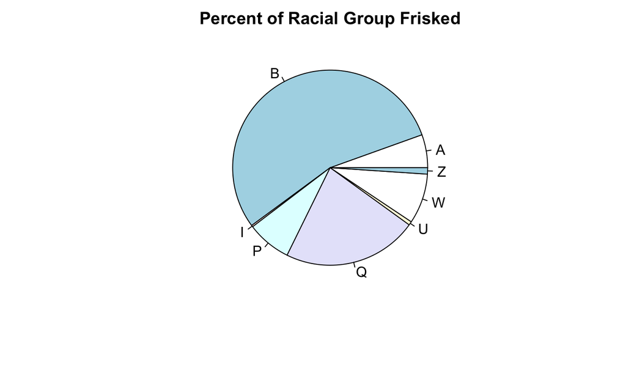

```r
# Creating inputs for graphs
slices <- c(f.a,f.b,f.i,f.p,f.q,f.u,f.w,f.z)
lbls <- c("A","B","I","P","Q","U","W","Z")
# Setting up png export, and generating graphs
pie <- pie(slices,lbls, main = "Percent of Racial Group Frisked")
```

```r
bar <- barplot(slices, names.arg = lbls, main = "Percent of Racial Group Frisked")
png("pie.png")
```

```r
pie(slices,lbls, main = "Percent of Racial Group Frisked")
dev.off()
```

```r
png("bar.png")
barplot(slices, names.arg = lbls, main = "Percent of Racial Group Frisked")
```

[figure not shown]

```r
dev.off()
```

### 3: Writing functions (40 Points)

Many of the variables in the stop and frisk data are coded as “Y” for “Yes” and “N” for no. You want to have an easy means of recoding every variable in the stop and frisk data set using a function that you define.

#### (a) (20 Points)

In order to save some time from having to recode every single variable that contains a “Y” or a “N”, write a function that transforms:

- “Y” codings to “1”
- “N” codings to “0”
- " " codings to “NA”

for a single variable and returns the recoded variable. Call this function “yesno”

```r
# YOUR CODE HERE
yesno<-function(oldvariable,newvariable,col){
   if (any(oldvariable=="Y") == TRUE) {
      for (i in (1:length(oldvariable))){
        if (oldvariable[i] == "Y"){
        newvariable[i,col+1] = "1"
        }
        if (oldvariable[i] == "N"){
        newvariable[i,col+1] = "0"
        }
        if (oldvariable[i] == " "){
        newvariable[i,col+1] = "NA"
        }
      }
    }
  else{print('nope')}
  return(newvariable)
}
```

#### (b) (20 Points)

Using the function that you defined in part (a), write a loop that transforms every single variable in the “stopandfrisk2016” data frame containing a “Y” or “N” coding into “1”, “0” or “NA” codings as specified above.

Save these newly coded variables in a data frame called “recoded” and use the “head()” function to print out the first few observations of the new dataframe that you created.

```r
recoded <- data.frame()
nope=0
for (j in 1:112){
    if (is.factor(stopandfrisk2016[,j]) == TRUE){
      recoded <- yesno(stopandfrisk2016[,j],recoded,ncol(recoded))
      col.name <- colnames(stopandfrisk2016[j])
      colnames(recoded)[ncol(recoded)] <- col.name
    }
    else {
      nope <- nope + 1
      print(nope)}
}
```

[output not shown]

[output cut: 19 more lines]

```
Error in if (oldvariable[i] == "Y") { :
  missing value where TRUE/FALSE needed
```

### 4: Logistic regression (Extra Credit, 10 Points)

Estimate a logistic regression model using the “frisked” variable as your dependent variable and with 5 independent variables of your choosing. Calculate odds ratios for each of the independent variables that you included in the model and print out the odds ratios.

Interpret the odds ratios for one your independent variables.

```r
# YOUR CODE HERE
```